# Lab 2: Demographic analysis in R

Brad Anderson

January 18, 2019

### Entering the Model

**1. Print the matrix you have just created, and ensure that it matches the one in Table 2 of Crowder et al. (1994) (linked on the GauchoSpace page)**

```
##            Egg Sm Juv Lg Juv Subadult  Adult
## Egg      0.000  0.000  0.000    4.665 61.896
## Sm Juv   0.675  0.703  0.000    0.000  0.000
## Lg Juv   0.000  0.047  0.657    0.000  0.000
## Subadult 0.000  0.000  0.019    0.682  0.000
## Adult    0.000  0.000  0.000    0.061  0.809
```

**2. Print out the subsets of A described in the list above. Do you get the values you expect? Do you understand how matrix subsetting works? If not, what don’t you understand?**

```r
#elements (3,3) and (4,3)
A[3:4, 3]
```

```
##   Lg Juv Subadult
##    0.657    0.019
```

```r
#columns 3 and 5
A[ , c(3,5)]
```

```
##          Lg Juv  Adult
## Egg       0.000 61.896
## Sm Juv    0.000  0.000
## Lg Juv    0.657  0.000
## Subadult  0.019  0.000
## Adult     0.000  0.809
```

```r
#everything except the first row.
A[-1, ]
```

```
##            Egg Sm Juv Lg Juv Subadult Adult
## Sm Juv   0.675  0.703  0.000    0.000 0.000
## Lg Juv   0.000  0.047  0.657    0.000 0.000
## Subadult 0.000  0.000  0.019    0.682 0.000
## Adult    0.000  0.000  0.000    0.061 0.809
```

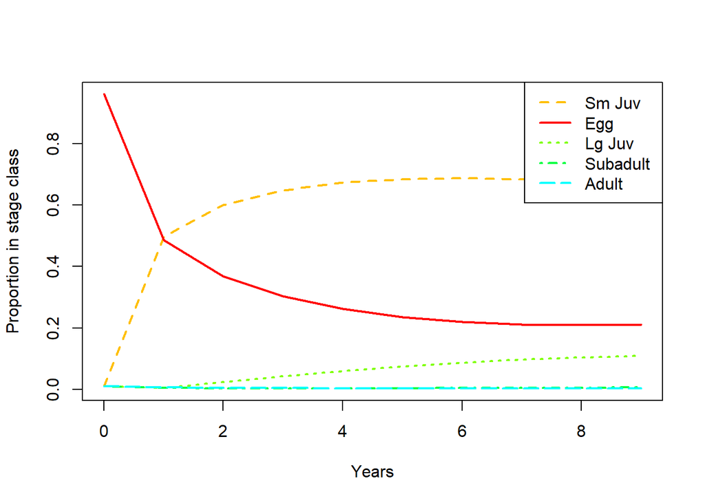

```r
library(popbio) # You may need to install this first with install.packages("popbio")
n_0 <- c(1000, 10, 10, 10, 10) # Initial abundance
pop <- pop.projection(A, n_0, iterations = 10) # Project the matrixpop
stage.vector.plot(pop$stage.vector) # Plot each stage through time
```

**4. The output of pop.projection has a number of other elements besides stage.vector. Describe what they are.**

```r
pop
```

```
## $lambda
## [1] 0.9211549
##
## $stable.stage
##         Egg      Sm Juv      Lg Juv    Subadult       Adult
## 0.211083402 0.671087214 0.108936804 0.006133496 0.002759084
##
## $stage.vectors
##             0      1         2           3           4           5
## Egg      1000 665.61 571.19685  485.036481  411.289802  351.626280
## Sm Juv     10 682.03 928.75384 1038.471823 1057.445316 1021.004674
## Lg Juv     10   7.04  36.68069   67.750644   93.320349  111.011399
## Subadult   10   7.01   4.91458    4.048677    4.048460    4.534136
## Adult      10   8.70   7.46591    6.339711    5.375795    4.595974
##                   6          7          8          9
## Egg      305.624171 271.522516 246.937023 229.398165
## Sm Juv   955.114025 877.741474 800.329955 729.314449
## Lg Juv   120.921709 124.335922 122.942550 118.388763
## Subadult   5.201497   5.844934   6.348627   6.665672
## Adult      3.994726   3.549024   3.227702   2.998477
##
## $pop.sizes
##  [1] 1040.000 1370.390 1549.012 1601.647 1571.480 1492.772 1390.856
##  [8] 1282.994 1179.786 1086.766
##
## $pop.changes
## [1] 1.3176827 1.1303438 1.0339800 0.9811646 0.9499152 0.9317268 0.9224490
## [8] 0.9195569 0.9211549
```

lambda: The popbio package estimates lambda using the change between the last two population counts. If I ran this with enough iterations this would reach the asymptotic value. stable.stage: proportions of each life stage calss in last stage iteration stage.vector: “a matrix with the number of projected individuals in each stage class”" pop.sizes: “Total number of projected individuals” pop.changes: “Proportional change in population size”

**5. Plot pop$pop.sizes and pop$pop.changes through time. What do these tell you?**

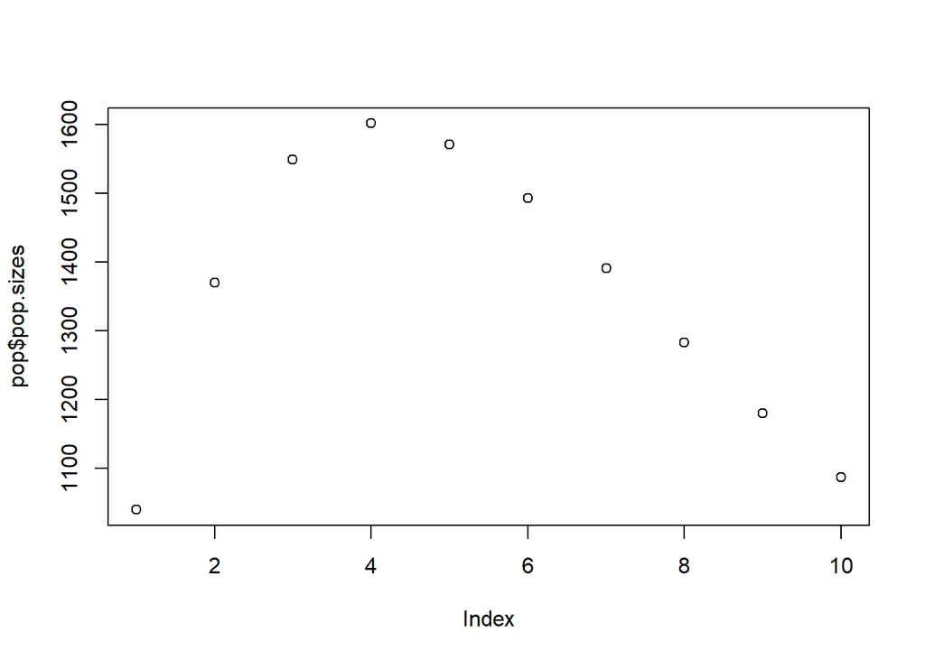

```r
plot(pop$pop.sizes)
```

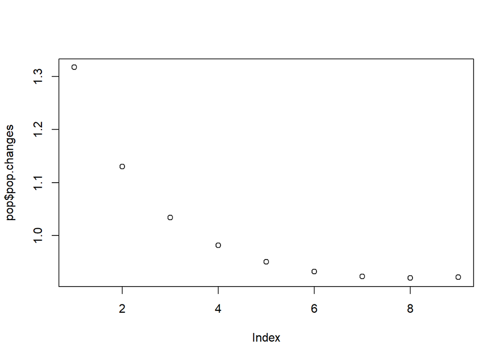

```r
plot(pop$pop.changes)
```

These shows that the number of individuals decreases after time=4.

**6. Once the population has reached the stable stage distribution (SSD), all stages will grow or decline exponentially with the same growth rate. Looking at the stage vector plot, has this been achieved by the end of your simulated time series? (Tip: this might be easier to determine if you make the plot with abundance on a log scale. You can do this by including log = “y” in the call to stage.vector.plot)**

It has not reached SSD.

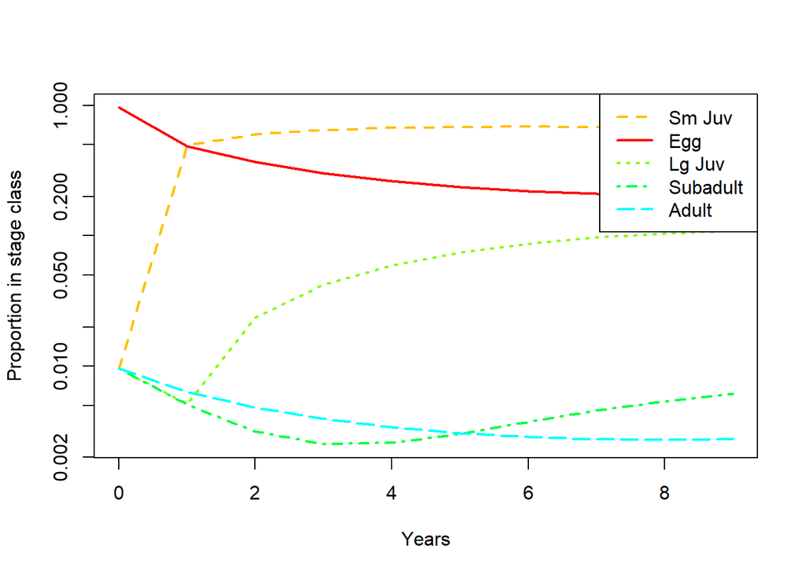

```r
stage.vector.plot(pop$stage.vector, log = "y")
```

**7. If the population has not reached the SSD, run the simulation for longer. How many years are required before the population appears to be at the SSD?**

It takes ~20 years for the population to be at SSD.

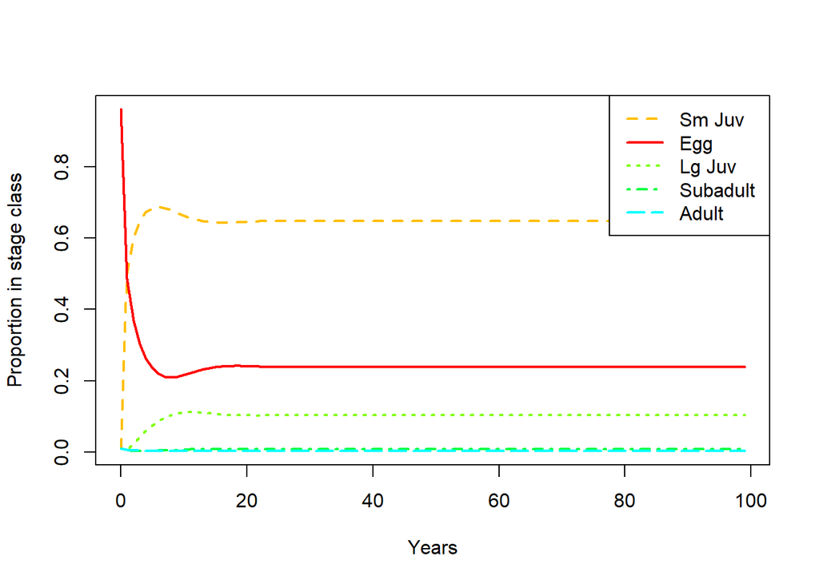

```r
pop100 <- pop.projection(A, n_0, iterations = 100) # Project the matrixpop
stage.vector.plot(pop100$stage.vector) # Plot each stage through time
```

### Analyzing the Population Matrix

**8. Compare the values of lambda and SSD with the equivalent outputs of pop.projection from the initial run (with only 10 years of simulation). Why are they different?**

The initial run of ten years produces a lambda of 0.9211549, which is less than the actual lambda of 0.9515489. This is because not enough time was alotted for the population to reach SSD, where all stages will grow or decline at the same rate.

```r
lambda(A)
```

```
## [1] 0.9515489
```

```r
stable.stage(A)
```

```
##         Egg      Sm Juv      Lg Juv    Subadult       Adult
## 0.238508404 0.647732505 0.103356123 0.007285382 0.003117586
```

**9. You want to improve the status of the population so that it is no longer declining. You think that your best options are to manage the nesting beaches to increase egg/hatchling survival (e.g., controlling poaching, motorized vehicles, dogs, bright lights that disorient hatchlings) or to reduce the bycatch of adult turtles in shrimp trawling nets (e.g., by requiring a modified design with a “turtle excluder device” or by reducing fishing effort). Use the model to evaluate the effects of these two strategies:**

**a. Which element of the projection matrix represents egg/hatchling survival? Which represents adult survival?**

egg/hatchling survival = [2,1] adult survival = [5,5]

**b. Increase egg/hatchling survival in the model, and re-calculate λ1. By how much does it increase? Experiment with different values of this survival term until you get an asymptotic growth rate of 1 or more. How large does egg survival need to be to achieve this?**

By increasing the egg/hatchling survival to 0.80 it increases lambda from 0.9515489 to 0.9611348.

```r
egg <- matrix(c(0, 0, 0, 4.665, 61.896,
                0.8, 0.703, 0, 0, 0,
                0, 0.047, 0.657, 0, 0,
                0, 0, 0.019, 0.682, 0,
                0, 0, 0, 0.061, 0.809),
nrow = 5, ncol = 5, byrow = TRUE, dimnames = list(class_names, class_names))

lambda(egg)
```

```
## [1] 0.9611348
```

**c. Put the egg survival back to its original value, increase adult survival in the model, and re-calculate λ1. By how much does it increase? Experiment with different values of this survival term until you get an asymptotic growth rate of 1 or more. How large does adult survival need to be to achieve this?**

I need to increase the adult survival to between 0.92 and 0.93 to reach a lambda of 1.

```r
adult <- matrix(c(0, 0, 0, 4.665, 61.896,
                0.675, 0.703, 0, 0, 0,
                0, 0.047, 0.657, 0, 0,
                0, 0, 0.019, 0.682, 0,
                0, 0, 0, 0.061, 0.93),
nrow = 5, ncol = 5, byrow = TRUE, dimnames = list(class_names, class_names))

lambda(adult)
```

```
## [1] 1.003739
```

**d. Based on this analysis, which life stage seems the more promising one to target management at? What else would you need to know to reach a final conclusion?**

The adult life stage is more promising. Even if I set the egg survival to “1” I do not reach a lambda of 1. In order to reach a final conclusion I would need to know the feasibility of increasing adult survival. As these turtles live out at see, it would be difficult to affect adult survival. Increasing egg/hatchling survival is likely easier because it occurs on beaches where we can more easily protect them.